# Covid-19 Analysis

## Presentazione del Report

Analisi della situazione italiana del Covid-19 basata sui dati della Protezione Civile. I dati sono aggiornati alle 18.30 e sono recuperati dal repository https://github.com/pcm-dpc/COVID-19. Per aggiornare i dati rilanciare il presente Notebook.

> Questo Report è stato sviluppando usando Jupyter Lab un tool che permette la scrittura di codice Python tramite Browser. Il codice sorgente è disponibile all'indirizzo https://github.com/pasalino/Covid-19-PyAnalysis .

> **Sono gradite le Star (stelline in alto a destra della pagina).**  
> Sono graditi commenti e suggerimenti che potete inviare all'indirizzo pasalino@gmail.com oppure sulla pagina https://github.com/pasalino/Covid-19-PyAnalysis/issues .  
> Qui tutte le nuove funzionalità e la Roadmap del report https://pasalino.github.io/Covid-19-PyAnalysis

## Disclosure e scarico di responsabilità

Questo report non vuole sostituirsi alle fonti ufficiali, ma ne va a completamento. Non consideratelo una fonte ufficiale ma una lettura dei dati ufficiali da un punto di vista matematico. Non mi ritengo responsabile della diffusione di questo report se non nei limiti delal condivisione di pensiero atta a comprendere meglio i dati. I dati in questo report, non sono analizzati da esperti di settore e quindi proni ad errori. Potrebbero esserci errori e inesattezze nel codice che produce i dati. Attraverso la pagina sopra indicata è possibile indicarle.

## Ultimo aggiornamento dei dati dalla protezione civile

Questa data è l'ultimo aggiornamento ai dati della protezione civile a cui si riferisce questo Report

**Sat Mar 28 18:27:59 2020 +0100**

## Dati Nazionali

### I dati cumulati di oggi

|  | RICOVERATI | TERAPIA INT. | TOT. RICOV. | ISOLAME. DOM. | TOT. POSITIVI | GUARITI | DECEDUTI | CASI TOTALI | TAMPONI |
| --- | --- | --- | --- | --- | --- | --- | --- | --- | --- |
| 28-Mar-20 | 26676 | 3856 | 30532 | 39533 | 70065 | 12384 | 10023 | 92472 | 429526 |

### I dati di oggi

|  | RICOVERATI | TERAPIA INT. | TOT. RICOV. | ISOLAME. DOM. | NUOVI CASI | GUARITI | DECEDUTI | CASI TOTALI | TAMPONI |
| --- | --- | --- | --- | --- | --- | --- | --- | --- | --- |
| 28-Mar-20 | 647 | 124 | 771 | 2880 | 3651 | 1434 | 889 | 5974 | 35447 |

#### Grafico della progressione giornaliera

Ogni punto indica il numero di casi evidenziati in quel giorno

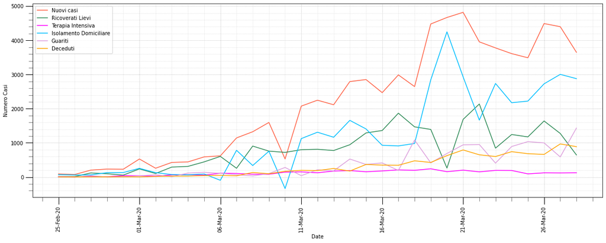

#### I dati degli ultimi 5 giorni

|  | RICOVERATI | TERAPIA INT. | TOT. RICOV. | ISOLAME. DOM. | NUOVI CASI | GUARITI | DECEDUTI | CASI TOTALI | TAMPONI |
| --- | --- | --- | --- | --- | --- | --- | --- | --- | --- |
| 24-Mar-20 | 1245 | 192 | 1437 | 2175 | 3612 | 894 | 743 | 5249 | 21496 |
| 25-Mar-20 | 1175 | 93 | 1268 | 2223 | 3491 | 1036 | 683 | 5210 | 27481 |
| 26-Mar-20 | 1641 | 123 | 1764 | 2728 | 4492 | 999 | 662 | 6153 | 36615 |
| 27-Mar-20 | 1276 | 120 | 1396 | 3005 | 4401 | 589 | 969 | 5959 | 33019 |
| 28-Mar-20 | 647 | 124 | 771 | 2880 | 3651 | 1434 | 889 | 5974 | 35447 |

### Andamento Nazionale

I dati cumulati nei giorni. Ci da idea di come sta evolvendo l'epidemia.

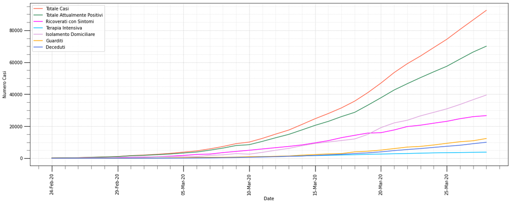

#### I dati degli ultimi 5 giorni

|  | RICOVERATI | TERAPIA INT. | TOT. RICOV. | ISOLAME. DOM. | TOT. POSITIVI | GUARITI | DECEDUTI | CASI TOTALI | TAMPONI |
| --- | --- | --- | --- | --- | --- | --- | --- | --- | --- |
| 24-Mar-20 | 21937 | 3396 | 25333 | 28697 | 54030 | 8326 | 6820 | 69176 | 296964 |
| 25-Mar-20 | 23112 | 3489 | 26601 | 30920 | 57521 | 9362 | 7503 | 74386 | 324445 |
| 26-Mar-20 | 24753 | 3612 | 28365 | 33648 | 62013 | 10361 | 8165 | 80539 | 361060 |
| 27-Mar-20 | 26029 | 3732 | 29761 | 36653 | 66414 | 10950 | 9134 | 86498 | 394079 |
| 28-Mar-20 | 26676 | 3856 | 30532 | 39533 | 70065 | 12384 | 10023 | 92472 | 429526 |

### Growth rate %. Fattori di crescita

I fattori di crescita sono valori percentuali che di danno idea rispetto al giorno prima di come si muove l'epidemia e la sua velocità.

|  | NUOVI CASI | TOT. POSITIVI | RICOVERATI | TERAPIA INT. | ISOLAME. DOM. | GUARITI | DECEDUTI | TAMPONI |
| --- | --- | --- | --- | --- | --- | --- | --- | --- |
| 28-Mar-20 | -17.04 | 5.5 | 2.49 | 3.32 | 7.86 | 13.1 | 9.73 | 8.99 |

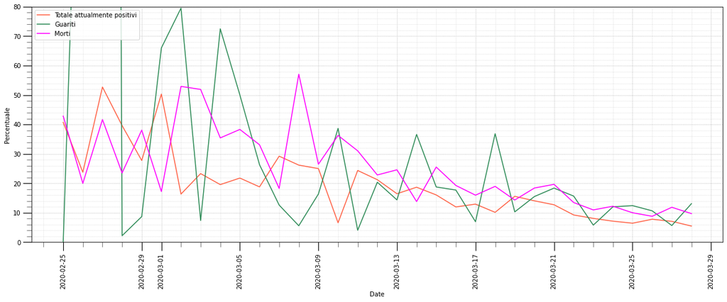

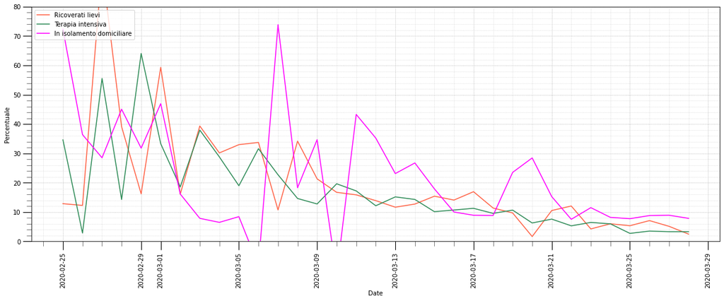

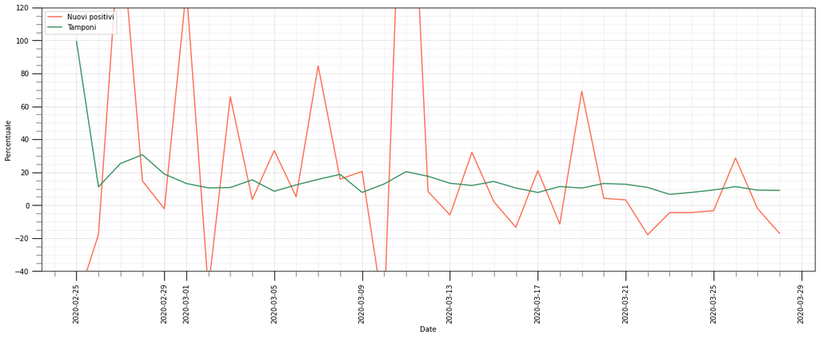

#### I dati degli ultimi 5 giorni

I valori sono in percentuale

|  | NUOVI CASI | TOT. POSITIVI | RICOVERATI | TERAPIA INT. | ISOLAME. DOM. | GUARITI | DECEDUTI | TAMPONI |
| --- | --- | --- | --- | --- | --- | --- | --- | --- |
| 24-Mar-20 | -4.44 | 7.16 | 6.02 | 5.99 | 8.20 | 12.03 | 12.23 | 7.80 |
| 25-Mar-20 | -3.35 | 6.46 | 5.36 | 2.74 | 7.75 | 12.44 | 10.01 | 9.25 |
| 26-Mar-20 | 28.67 | 7.81 | 7.10 | 3.53 | 8.82 | 10.67 | 8.82 | 11.29 |
| 27-Mar-20 | -2.03 | 7.10 | 5.15 | 3.32 | 8.93 | 5.68 | 11.87 | 9.15 |
| 28-Mar-20 | -17.04 | 5.50 | 2.49 | 3.32 | 7.86 | 13.10 | 9.73 | 8.99 |

### Trends e medie

Uno spaccato di alcuni dati. Viene visualizzato anche il trend medio settimanale. GR = Growth Rate - Fattore di crescita

|  | NUOVI CASI | GR(%) | MEDIA 7GG (%) | TAMPONI | GR(%) | MEDIA 7GG (%) | DECEDUTI | GR(%) | MEDIA 7GG (%) |
| --- | --- | --- | --- | --- | --- | --- | --- | --- | --- |
| 24-Mar-20 | 3612 | -4.44 | 5.49 | 21496 | 7.80 | 10.41 | 743 | 12.23 | 15.44 |
| 25-Mar-20 | 3491 | -3.35 | 6.64 | 27481 | 9.25 | 10.11 | 683 | 10.01 | 14.16 |
| 26-Mar-20 | 4492 | 28.67 | 0.85 | 36615 | 11.29 | 10.24 | 662 | 8.82 | 13.37 |
| 27-Mar-20 | 4401 | -2.03 | -0.04 | 33019 | 9.15 | 9.66 | 969 | 11.87 | 12.44 |
| 28-Mar-20 | 3651 | -17.04 | -2.94 | 35447 | 8.99 | 9.13 | 889 | 9.73 | 11.02 |

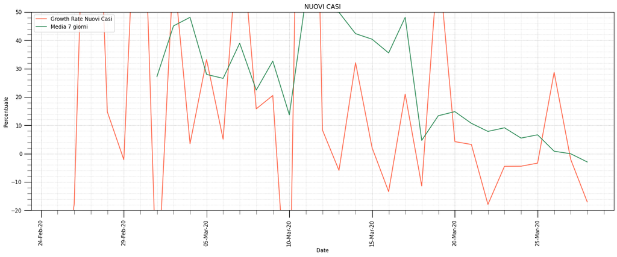

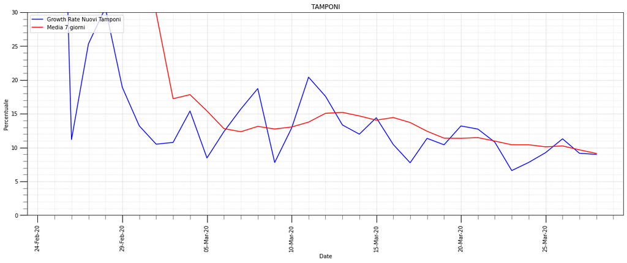

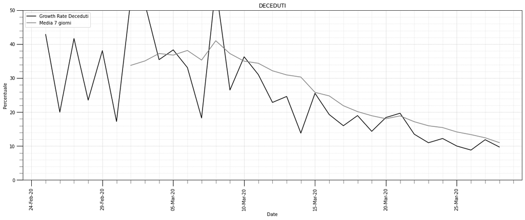

### Divisione percentuali dei casi

Un indicazione percentuale dei dati. La fotografia ad oggi (dall'inizio dell'epidemia italiana)

[figure not shown]

Lo spaccato giorno per giorno percentuale. Da qui si evidenzia come si evolve l'andamento percencentuale dell'epidemia. In basso (in verde) il grafico del Growth Rate di ogni giorno rispetto al giorno precedente. Per capire come si evolvono le percentuali in base all'aumento o la diminuzione dei nuovi casi.

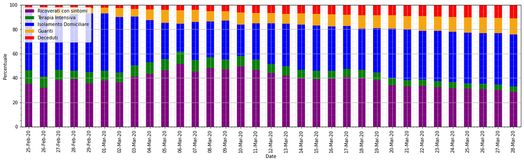

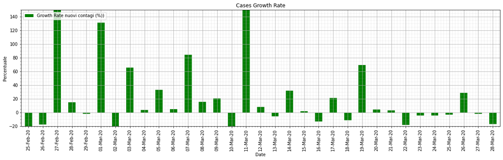

## DATI REGIONALI

> IN ARRIVO